# Accounting, Analysis and Governance in Complex Deals

Arndt Weinrich

weinrich@rsm.nl

Rotterdam School of Management

# Cross Border Issues

> **BMME303**

> Accounting, Analysis and Governance in Complex Deals

## Roadmap

### Cross Border Issues in CoDE

1. **Foreign Market Entry**: Motives and Strategy
2. Selected **Issues**:
   1. Failure
   2. Currency Conversion
   3. Policy Uncertainty
   4. Tariffs

## Relevant Learning Goals

### Cross Border Issues in CoDE

**Session Learning Goals**

- Motives for international expansion
- Common international market entry strategies
- Specifics of the Cross-Border M&A Process

**Relevant Course Learning Objective**

- Critically assess complex multi-type and multi-source information in transaction-related valuations and decisions

# What Motivates Firms To Acquire a Firm in Another Country?

**Let’s Discuss** → **MentiMeter**

## What Motivates Firms To Acquire a Firm in Another Country?

### Menti-Results

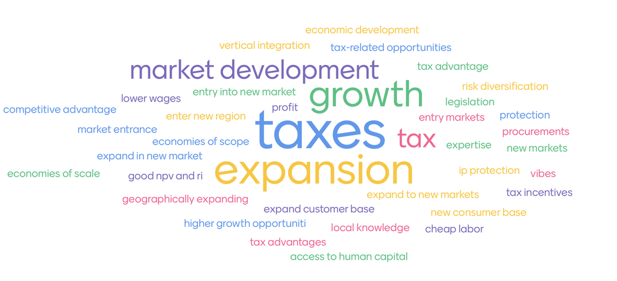

## Motivation

### Cross Border Issues in CoDE

> “Such factors include differences in **economic development, laws, institutions, culture, labor rights, protection of intellectual property, taxes, and corporate governance**”

> Erel, Jang, and Weisbach (2022)

*See also Erel, Liao, and Weisbach (2012), and Bilgili (2024) for review of research on cross-border M&A*

## Motivation

### Cross Border Issues in CoDE (DePamphilis 2025)

- Geographic and Industrial Diversification
- **Accelerating Growth**
- Industry Consolidation
- Utilization of Lower Raw Material and Labor Costs
- Leveraging Intangible Assets
- Minimizing Tax Liabilities
- Seeking More Management Friendly Environments
- Avoiding Entry Barriers
- Fluctuating Exchange Rates
- **Following Customers**
- Gaining Access to **Intellectual Property** and Resources

## Market Entry Strategy

### Cross Border Issues in CoDE (DePamphilis 2025)

> “[…] market entry chosen by a firm may reflect the firm’s risk tolerance, competitive conditions, overall resources, and degree of CEO overconfidence. **Common entry strategies include M&As, solo ventures, joint ventures, export, and licensing.**”

> DePamphilis (2025)

$\rightarrow$ What is a Solo Venture?

$\rightarrow$ What are (dis)advantages of choosing M&A over Solo Ventures for foreign market entry?

## Solo Venture?

### Cross Border Issues in CoDE

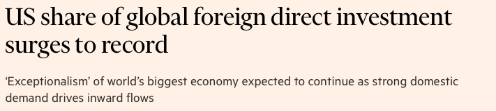

> In a solo venture (Greenfield Investment) a parent company establishes new business operations (e.g., subsidiary or branch) in a foreign country (foreign direct investment) from scratch. These new operations can include facilities, offices, and employees, in contrast to situations where the parent intends buying or partnering with an existing business.

## Greenfield Investment

### Cross Border Issues in CoDE

Advantages

- Complete control over operations and strategy
- No acquisition premium to pay
- Purpose-built facilities with exact specifications
- No hidden liabilities or legacy issues

Disadvantages

- Significantly slower time to market
- Higher initial capital investment
- Lack of local market knowledge and relationships
- No immediate customer base or revenue

*See Appendix 1 in Harzing (2002) for a comprehensive overview*

# Failure

**Selected Issues**

## Failure

### From Motivation, to Strategy, to Success?

> **Cross-border M&As often are perceived as much more risky than domestic deals**

**Why?**

- Cultural Differences
- Regulatory Complexity
- Currency Risk
- […]?

## Failure

### From Motivation, to Strategy, to Success?

*Notes*

**Cultural Differences:**

- Organizational culture conflicts
- National cultural differences affecting management styles
- Language barriers complicating both negotiation and integration
- Example: Differences in directness of communication or attitudes toward hierarchy

## Failure

### From Motivation, to Strategy, to Success?

*Notes*

**Regulatory Complexity:**

- Multiple regulatory regimes to navigate simultaneously
- Antitrust/competition law differences across jurisdictions
- Employment law variations affecting integration planning
- Example: EU labor protections versus more “flexible” employment in the US

## Failure

### From Motivation, to Strategy, to Success?

*Notes*

**Currency Risk:**

- Exchange rate fluctuations between deal signing and closing
- Long-term currency trends affecting the value of the investment
- Potential currency conversion restrictions in some markets
- Example: Significant devaluations affecting the actual cost of acquisition or post-acquisition returns

**Add:**

- Tax, Information Asymmetry (Governance), Litigation, Trade Secrecy, Rule of Law …

## Daimler-Chrysler Case Study

### Cross Border Issues in CoDE: Failure

**Background**

- **Type:** Merger/Consolidation between Daimler-Benz (Germany) and Chrysler Corporation (USA)
- **Deal Value:** USD 36bn in 1998 (stock swap with Daimler shareholders receiving 57%)
- **Objective:** Create a transatlantic auto giant and leverage synergies in engineering, production, and markets

*See this Ask FT [summary](https://ask.ft.com/answer/e52cd0b2-7d32-4e42-9931-1805733d1e60) and this [timeline](https://www.ft.com/content/6109186c-0209-11dc-ac32-000b5df10621). A stock swap is a form of payment: shares of one company are exchanged for another to pay for an acquisition (more on this in lecture on payment).*

**$\Rightarrow$ Initial Hype: promoted as a merger of equals**

## Daimler-Chrysler

### Failure

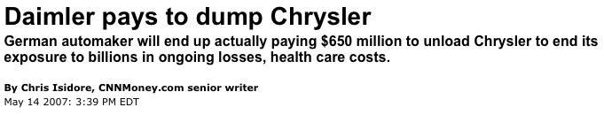

- Daimler sold Chrysler in 2007 for **USD 7.4 billion** (effectively way less)
- Seen as a textbook failure in international M&A execution

What happened?

## Daimler-Chrysler

### Failure

**Cultural Clash**

- German hierarchical, engineering-led culture vs. American informal, market-driven approach
- Misalignment in decision-making styles and corporate governance

**Integration Mismanagement**

- Lack of a unified strategy
- Poor coordination across operations, especially in product development and marketing

## Daimler-Chrysler

### Failure

**Leadership & Trust Issues**

- Power imbalance (Daimler gradually took control)
- Resentment among Chrysler executives and talent drain

**Market Misjudgment**

- Overestimation of synergies
- Chrysler’s declining performance post-merger hurt overall valuation

## Beyond Financials

### Failure

Cultural Clash?

> *But what isn’t practiced, and too often ignored, is the process of asking: “What are the likely challenges we will face as we integrate these two complex companies over the next 1-2 years?”*

> Fubini (2014)

→ successful cross-border M&A requires looking beyond financial metrics to assess cultural and organizational compatibility

## Beyond Financials

### Failure

Key Steps

- Assess Institutional Strengths
- Understand Cultural Dynamics
- **Doing a stakeholder analysis to understand the additional challenges from political, regulatory, union, and community sources to be expected**

Cultural differences aren’t inherently negative → they can be sources of value if properly leveraged

# How Detrimental Are Failed Mergers?

## How Detrimental Are Failed Mergers?

### Failed Mergers Revisited

Innovation

> *“[…] relative to failed targets, firms acquired in diversifying mergers produce both a smaller number of innovations and also less-novel innovations, where innovations are measured using patent-based metrics.”*

> Seru (2014)

## How Detrimental Are Failed Mergers?

### Failed Mergers Revisited: Seru (2014)

- **Research Question:** How does the conglomerate form (established through M&A) affect innovation?
- **Identification:** treatment: targets taken over in friendly mergers; control: targets whose mergers **failed to go through**
- **Theory/Tension:** conglomerates may accelerate at directing investments but such internal capital markets also come with substantial **information asymmetries** between researchers & managers
- **Finding:** firms in treatment group face a significant decline in novelty of their research

**→ challenges the conventional assumption (?) that mergers enhance capabilities**

## How Detrimental Are Failed Mergers?

### Failed Mergers Revisited: Seru (2014)

*Notes*

**Implications:**

- Companies that are acquisition targets but where deals fell through may actually perform better on innovation metrics than those that are acquired
- This suggests mergers can sometimes disrupt valuable innovation processes
- The paper specifically looks at patent quantity and quality as innovation metrics

## How Detrimental Are Failed Mergers?

### Failed Mergers Revisited: Seru (2014)

*Notes*

**Specific Mergers:** The focus is on “diversifying mergers” specifically (where acquirer and target are in different industries), not all mergers.

**Identification Strategy:** Failed mergers establish the “control group” to isolate the effects of being acquired, addressing the challenge that acquisition targets aren’t randomly selected.

**Failure**

- Cross-border deals bring many unique challenges beyond those in domestic deals
- Many of these challenges are **soft** factors related to culture, communication, and expectations
- Understanding stakeholder concerns from political, regulatory, union, and community perspectives is crucial
- Failed mergers are not per se detrimental (e.g., Seru (2014))

**$\Rightarrow$ the complexity of cross-border deals makes proper archetype selection and implementation even more critical**

# Currency Conversion

**Selected Issues**

## Foreign Target Cash Flows

### Cross Border Issues in CoDE

Task

> **Converting foreign target cash flows to acquirer domestic cash flows (assume: USD acquirer & EUR target)**

Approach

> **Predict forward (future spot) exchange rates based on interest rate parity (IRP) or purchasing power parity (PPP)** **theories**

## Interest Rate Parity Theory

### Convert Foreign Target Cash Flows

Terminology

- Spot exchange rate USD/EUR ($/€) = the current number of dollars required to buy one Euro
- Forward exchange rate = the rate at which a bank is willing to exchange dollars for Euro at some specified future date
- **Interest Rate Parity = forward exchange rates are determined by differences between interest rates in the two countries**

## Why Do We Need a Theory? Example

### Interest Rate Parity Theory

> **Assume** that you (U.S.) have $10M to invest, and that interest rates in the U.S. and the U.K. are 8% and 12%, respectively. The current spot exchange rate is $1.60/£ (the current number of dollars required to buy one Pound), and the one-year forward exchange rate is $1.53/£.

> *Where should you invest your money?*
- Convert USD using spot rate: $10m ÷ ($1.60/£) = £6.25m
- Invest at foreign interest rate: £6.25m × 1.12 = £7m
- Convert back at forward rate: £7m × ($1.53/£) = $10.71m
- Compare home nation investment: $10m × (1 + 0.08) = $10.8m

**$\Rightarrow$ But?**

## Why Do We Need a Theory?

### Interest Rate Parity Theory

Example cont’d

- Under these assumptions, **arbitrage** opportunities exist!
  - Borrow Pounds (e.g. £1m) at 12% interest rate in the U.K. = £1.12m
  - Convert to dollars at the spot rate: £1m × ($1.60/£) = $1.6m
  - Invest at home interest rate: $1.6m × 1.08 = $1.728m
  - Convert back at forward rate: $1.728m ÷ ($1.53/£) = £1.129m

$\rightarrow$ **Per 1m pounds borrowed, you would make 9,000 pounds risk-free by borrowing in the U.K., converting to dollars, investing in the U.S., and converting back at the forward rate**

## Why Do We Need a Theory?

### Interest Rate Parity Theory

Example cont’d

> *“There’s no free lunch.”*

$\rightarrow$ efficient markets **eliminate arbitrage opportunities** through supply and demand effects on interest rates and exchange rates

$\rightarrow$ forward exchange rate changes until investors are indifferent between investing in the U.S. and the U.K. (i.e., no arbitrage profit opportunities)

$\rightarrow$ forward exchange rate is a function of the current spot exchange rate and the interest rate differential between the two countries: **interest rate parity theory**

## Interest Rate Parity Theory

### Convert Foreign Target Cash Flows

Core Principle

> **The forward exchange rate should offset interest rate differences, making investors indifferent between countries**

**Mechanism**

- The future exchange rate is expected to appreciate/depreciate based on the interest rate differential between the two countries
- Otherwise, arbitrage profit opportunities would exist: resulting supply/demand effects move exchange rates until parity is restored

## Interest Rate Parity Theory

### Convert Foreign Target Cash Flows

**Elimination of Arbitrage?**

- Example: Assume US interest rates rise above EU rates:
  - Investors convert euros into dollars at the spot rate $\rightarrow$ USD **spot rate** appreciates
  - They sell dollars forward to hedge exchange risk $\rightarrow$ USD **forward rate** depreciates
- **Interest Rate Parity**: the spot rate will appreciate and forward rate depreciate until the profit derived from the interest rate difference is erased

## Interest Rate Parity Theory

### Notes

*Notes* (from DePamphilis (2025)):

For developed nations, the interest rate parity theory provides a framework for estimating forward currency exchange rates (i.e., future spot exchange rates). According to this theory, the percentage difference in the forward rate relative to the spot rate should be approximately equal to the difference in interest rates. If true, investors should not be able to profit from differences in interest rates because the forward rate should be set so that an investor would be indifferent between investing in the two different countries once the investor translates the profit back into his/her home currency.

## Interest Rate Parity Theory

### Notes

*Notes* (from DePamphilis (2025)):

For example, if U.S. interest rates rise relative to those in the EU, investors will buy dollars with euros at the current spot rate and sell an equivalent amount dollars for euros in the forward market t periods in anticipation of receiving the proceeds of their investment at maturity. At that time, these investors will convert the proceeds from dollars to Euros. These actions cause the Dollar/Euro spot rate to fall (i.e., the dollar appreciates in the spot market due to the increased supply of Euros offered to buy dollars) and the Dollar/Euro forward rate to rise (USD/EUR)_t (S_t) (i.e., the dollar depreciates in the forward market due to the increased supply of dollars offered to buy euros). The spot rate will appreciate and forward rate depreciate until the profit derived from the interest rate difference is erased. At that point, investors should be indifferent between investing in the U.S. and Eurozone countries.

## Interest Rate Parity Theory

### Notes

*Notes* (from DePamphilis (2025)):

In practice, equilibrium between forward exchange rates and spot rates adjusted for the ratio of interest rates in the U.S. to those in Eurozone countries will be restored by a combination of an appreciating dollar-to-Euro spot exchange rates, depreciating dollar-to-Euro forward rates(, declining U.S. interest rates, and increasing interest rates in Eurozone countries. Interest rates on U.S. bids will decline as the investors bid up their prices and interest rates on Eurozone bonds of comparable risk and maturity will increase as investors sell these bonds and invest the proceeds in the U.S).

## Interest Rate Parity Theory

### Convert Foreign Target Cash Flows

$$\begin{aligned}
\frac{S_t}{S_0} &= \frac{(1 + i_{\$t})^t}{(1 + i_{€t})^t} \\
\\
S_t &= S_0 \times \frac{(1 + i_{\$t})^t}{(1 + i_{€t})^t}
\\
\end{aligned}$$

$$\begin{aligned}
\text{Where } S_t &= \text{Forward/projected USD/EUR exchange rate $t$ periods into the future} \\
S_0 &= \text{current USD/EUR spot rate} \\
i_{\$t} &= \text{Interest rate in US (domestic) in $t$} \\
i_{€t} &= \text{Interest rate in European Union (foreign) in $t$}
\end{aligned}$$

## Example

### Interest Rate Parity Theory

Case

## Example

### Interest Rate Parity Theory

| Year | FCFF_Target | Interest_Foreign | Interest_Domestic |
| --- | --- | --- | --- |
| 1 | 124.5 | 0.045 | 0.0425 |
| 2 | 130.7 | 0.047 | 0.0435 |
| 3 | 136.0 | 0.053 | 0.0455 |
| 4 | 145.0 | 0.040 | 0.0420 |

- Calculate (i) projected/forward spot rates and (ii) FCFF in USD for years 1-4
- How and why do the current spot rate and the projected spot rate in year 1 differ?

Your Turn!

## Example

### Interest Rate Parity Theory

**Projected Spot Rate**

$$S_t = S_0 \cdot \left( \frac{1 + i_{domestic}}{1 + i_{foreign}} \right)^t$$

Where:

- $S_t$ = Projected spot rate in year *t*
- $S_0$ = Current spot rate = 1.2044
- $i_{domestic}$ = US interest rate in year *t*
- $i_{foreign}$ = Foreign country interest rate in year *t*

## Example

### Interest Rate Parity Theory

**Year 1**

$$\begin{aligned}
S_1 = 1.2044 \cdot \left( \frac{1.0425}{1.045} \right)^1 \\
\\
S_1 = 1.2015
\end{aligned}$$

**1.2044 ≠ 1.2015 (?)**

- Projected rate at $S_1$ includes the effect of one year of interest rate differential → $S_0$ ≠ $S_1$
- Unless the domestic and foreign interest rates are exactly equal, $S_1$ will deviate from the $S_0$

## Example

### Interest Rate Parity Theory

**Year 1**

$$\begin{aligned}
\text{FCFF}_\text{USD} = \text{FCFF}_\text{Target} \cdot S_t \\
\\
FCFF_{USD1} = 124.5 \cdot 1.2015 \\
\\
FCFF_{USD1} = 149.59
\end{aligned}$$

## Example

### Interest Rate Parity Theory

**Years 1-4**

- Solution
- Code

| Year | FCFF_Target | i_Foreign | i_Domestic | Proj. Spot Rate (USD/EUR) | FCFF in USD |
| --- | --- | --- | --- | --- | --- |
| 1 | 124.5 | 0.045 | 0.0425 | 1.2015 | 149.59 |
| 2 | 130.7 | 0.047 | 0.0435 | 1.1964 | 156.36 |
| 3 | 136.0 | 0.053 | 0.0455 | 1.1788 | 160.32 |
| 4 | 145.0 | 0.040 | 0.0420 | 1.2136 | 175.96 |

*Current spot rate = 1.2044 USD/EUR*

```r
library(tidyverse)

# FUNCTION
project_fcff_usd <- function(df, current_spot_rate) {

  # message
  print("Projecting Free Cash Flow to the Firm (FCFF) in USD using Interest Rate Parity (IRP)")
  print("assuming that current spot rate is given in USD/FOREIGN")

  # Ensure data is sorted by year
  df <- df[order(df$Year), ]

  # Initialize columns
  df$ProjectedSpotRate <- NA
  df$FCFF_USD <- NA

  # Calculate projected spot rates
    for (i in 1:nrow(df)) {
    # Time step
    t <- i
    # IRP formula with compounding
    df$ProjectedSpotRate[i] <- current_spot_rate *
      (((1 + df$Interest_Domestic[i])^t) / ((1 + df$Interest_Foreign[i])^t))
  }

  # Calculate FCFF in USD
  df$FCFF_USD <- df$FCFF_Target * df$ProjectedSpotRate

return(df)

}


# EXAMPLE DATA
example_df <- data.frame(
  Year = 1:4,
  FCFF_Target = c(124.5, 130.7, 136.0, 145),
  Interest_Foreign = c(0.045, 0.047, 0.053, 0.04),
  Interest_Domestic = c(0.0425, 0.0435, 0.0455, 0.042)
)

# CURRENT SPOT RATE
current_spot_rate <- 1.2044

# APPLY FUNCTION
project_fcff_usd(df = example_df, current_spot_rate)
```

## USD/EUR Spot Rates Over Time

### Interest Rate Parity Theory

[figure not shown]

**Currency Conversion**

- USD/EUR spot rate for us is *the current number of dollars required to buy one Euro*
- Increasing USD/EUR spot rate: during your trip to New York City, buying a T-Shirt with your Dutch debit card becomes cheaper

## USD/EUR Spot Rates since 2025

### Interest Rate Parity Theory

[figure not shown]

Currency Conversion

- Converting foreign target cash flows to acquirer domestic cash flows may require predicting future spot exchange rates
- Interest rate parity (IRP) theory provides a framework to derive these predictions
- Spot exchange rates substantially fluctuate over both short and long horizons

# Policy Uncertainty

**Selected Issues**

## Policy Uncertainty

### Cross Border Issues in CoDE

#### Definition

> **(Economic) policy uncertainty refers to uncertainty about who will make economic policy decisions, what economic policy actions will be undertaken and when, and the economic effects of those actions (or inaction)**

> Baker, Bloom, and Davis (2016)

## Policy Uncertainty

### Cross Border Issues in CoDE

#### Bringing our Definition to Life

> *“Examples of political and economic risk include excessive local government regulation, confiscatory tax policies, restrictions on cash remittances, currency inconvertibility, restrictive employment policies, expropriation of assets of foreign firms, civil war or local insurgencies, and corruption.”*

> DePamphilis (2025)

# Does Policy Uncertainty Affect M&A?

## Does Policy Uncertainty Affect Mergers and Acquisitions?

### Policy Uncertainty & M&A

> *“Political and regulatory uncertainty is strongly negatively associated with merger and acquisition activity at the macro and firm levels.”*

> Bonaime, Gulen, and Ion (2018)

**→ Let’s reconsider: why should it?**

**→ How can we confidently derive at this conclusion?**

## Policy Uncertainty & Mergers and Acquisitions

### Why?

#### Theory in Bonaime, Gulen, and Ion (2018)

- **Risk Management** (+): an increase in uncertainty encourages managers to operationally hedge via vertical integration (some evidence)
- **Empire Building** (+): exploit uncertainty for managers’ personal agendas while investor attention is low (not supported)
- **Interim Risk** (-): target value could change between announcement and deal completion (not supported)
- **Real option theory** (-): uncertainty increases the value of waiting to invest (strong empirical evidence) **→ fits intuitively to downside risks highlighted in DePamphilis (2025)**

Definition Real Option

## Real Option Theory in M&A

### Applications in Practice?

> *“[…] many companies hesitate to apply options theory to initiatives such as R&D and geographic expansion, partly because these real options are highly complex.”*

> Copeland and Tufano (2004)

→ Copeland and Tufano (2004) (available at [HBR Online](https://hbr.org/2004/03/a-real-world-way-to-manage-real-options)) suggest a decision/event tree implementation More

## Measuring Policy Uncertainty

### How?

> *“We develop a new index of economic policy uncertainty (EPU) based on newspaper coverage frequency. Several types of evidence—including human readings of 12,000 newspaper articles—indicate that our index proxies for movements in policy-related economic uncertainty.”*

> Baker, Bloom, and Davis (2016)

[PolicyUncertainty.com](https://www.policyuncertainty.com)

## Measuring Policy Uncertainty

### Baker, Bloom, and Davis (2016)

[figure not shown]

**Macro EPU**

- Substantial (recent) movement in uncertainty
- Graph: Trade Policy Uncertainty (tariffs are up next)
- Hassan et al. (2017) take measure from macro to firm-level

## More on Policy Uncertainty Effects

### Cross Border Issues in CoDE

[figure not shown]

**Alternative Measures & Identification Strategies**

- Gallemore et al. (2025): *“tax policy uncertainty can impact investment behavior”*
- Cao, Li, and Liu (2019): *“when a country is about to hold a national election, this deters foreign firms’ inbound acquisitions, especially when the host country poses greater expropriation risk.”*
- […]!

## Policy Uncertainty ?

### (Tax) Incentive Shopping

> *“In regimes with strict nexus requirements, reduced taxation of IP income is associated with reductions in the number of deals and the probability of being acquired for patent-owning firms due to the potential loss of eligibility for preferential taxation. This effect dissipates where nexus requirements are relaxed, and significant positive effects of IP box tax savings in more permissive regimes point to increased after-tax valuations of merger-driven synergies”*

> Bradley, Robinson, and Ruf (2021)

**→ Regulatory Arbitrage is not rare: acquisition flows involve acquirers from countries with stronger regulations than their targets (Karolyi and Taboada 2015)**

**Policy Uncertainty**

- EPU refers to uncertainty about who will make economic policy decisions, what economic policy actions will be undertaken and when, and their economic effects
- EPU is found to be negatively associated with M&A activity
- Why? uncertainty increases the value of waiting to invest (real option theory)
- Measurement becomes key: data, data, data…
- Firms can strategically exploit certain cross-border policy differences

**$\Rightarrow$ Managing policy (uncertainty) is crucial for successful cross-border deals**

# Tariffs

**Selected Issues**

## Tariffs

### Cross Border Issues in CoDE

> *“[…] one component of trade costs, tariffs, can actually be a reason for making a cross-border acquisition”*

> Erel, Jang, and Weisbach (2022)

Why?

**→ when tariffs are sufficiently high, firms will make cross border acquisitions or greenfield investments to avoid paying them**

**→ but! avoiding tariffs through FDI has been restricted by the [CJEU](https://chambers.com/articles/no-circumvention-of-eu-tariffs-by-relocating-production-the-harley-davidson-decision-of-the-cjeu) lately**

## Tariffs

### Cross Border Issues in CoDE

[figure not shown]

## Tariffs

### Cross Border Issues in CoDE

Statutory Incidence

> *“The costs of purchase of inventories comprise the purchase price, import duties and other taxes […]”* (IAS 2)
- Entities that directly purchase goods impacted by tariffs for their operations are likely to experience an **increase in costs** (e.g., see [PwC](https://viewpoint.pwc.com/dt/gx/en/pwc/in_briefs/in_briefs_INT/in_briefs_INT/tariffs-the-price-tag.html) on cost and disclosure, and [EY](https://www.ey.com/en_gl/insights/ifrs/accounting-considerations-for-potential-impact-of-tariffs) on impairments)
- Because tariffs are **paid by the importer** (purchaser) of the goods, *direct/mechanical* accounting implications for the seller of goods subject to a tariff are limited

## Tariffs

### Cross Border Issues in CoDE

Economic Incidence

> *Economic incidence (e.g., of a tariff) differs from statutory incidence (here importer) when passed through to others (e.g., customers)*
- **Impact of increased costs on M&A transactions?**
  - Hijzen, Görg, and Manchin (2008): trade costs affect cross-border merger activity negatively; their impact differs importantly across horizontal and non-horizontal deals (tariff-jumping for horizontal deals)
- What would change if firms **pass through** (likely?) tariffs?

# Cross Border Issues in CoDE

**Summary**

## Summary

### Cross Border Issues in CoDE

- **Cross Border Deals** introduce unique challenges and opportunities
- Key issues include:
  - **Failure Risks** (cultural, regulatory, currency, integration)
  - **Currency Conversion** (exchange rate risk, interest rate parity)
  - **Policy Uncertainty** (impact on deal timing and value, real options, arbitrage)
  - **Tariffs** (economic incidence, strategic responses)
- Success requires careful assessment of both *hard* (financial, legal) and *soft* (cultural, organizational) factors

## Thank You!

[figure not shown]

# Appendix

## Real Option Theory

### Copeland and Tufano (2004)

- A firm’s projects (e.g., research and development, investments in new capacity, **geographical expansion**, and other initiatives) are seldom simple onetime decisions; in most cases, a company’s investments are multistaged, and **at each step the company may push ahead or pull out after gaining new information.**
- These projects are thus **real options** (for financial options, see Black and Scholes (1973)): the right but not the obligation to invest

Back

## Real Option Theory

### Copeland and Tufano (2004)

Event Tree

1. Estimating what the value of the project would be if it existed today, a figure that may be derived from traditional non-option valuation techniques, such as discounted cash flow
2. The second step is estimating how much this value is likely to move up or down during the period in question

→ example? see Copeland and Tufano (2004)

Back

## Copyright

### © Erasmus University Rotterdam, all rights reserved. No text and data mining.

**English** This study material is protected by copyright under Dutch copyright laws. It is provided solely for your personal use and study. You are allowed to create a copy for your personal use. You are not allowed to make this study material or parts thereof available to others or reproduce it without prior written permission of the Erasmus University Rotterdam.

**Nederlands** Dit onderwijsmateriaal is een auteursrechtelijk beschermd werk in de zin van de Auteurswet. Het wordt in het kader van uw studie aan u ter beschikking gesteld en is uitsluitend bedoeld voor uw eigen persoonliike gebruik. U mag daarvoor een persoonliike kopie maken. Het verveelvoudigen en openbaar maken (waaronder begrepen het aan derden ter beschikking stellen en/of verspreiden) van dit onderwiismateriaal of een gedeelte daarvan is niet toegestaan zonder voorafgaande schrifteliike toestemming van de Erasmus Universiteit Rotterdam.

Titlepage photo by [Dennis Möller](https://unsplash.com/@ennismo?utm_source=unsplash&utm_medium=referral&utm_content=creditCopyText) on [Unsplash](https://unsplash.com/photos/city-skyline-under-blue-sky-during-night-time-946XeVrYO2E?utm_source=unsplash&utm_medium=referral&utm_content=creditCopyText)

## References

Baker, Scott R, Nicholas Bloom, and Steven J Davis. 2016. “Measuring Economic Policy Uncertainty.” *The Quarterly Journal of Economics* 131 (4): 1593–1636.

Bilgili, Tsvetomira V. 2024. “A Review of Research on Cross-Border Mergers and Acquisitions: Impact, Themes, and New Directions.” *Advances in Mergers and Acquisitions* 23: 1–17.

Black, Fischer, and Myron Scholes. 1973. “The Pricing of Options and Corporate Liabilities.” *Journal of Political Economy* 81 (3): 637–54.

Bonaime, Alice, Huseyin Gulen, and Mihai Ion. 2018. “Does Policy Uncertainty Affect Mergers and Acquisitions?” *Journal of Financial Economics* 129 (3): 531–58.

Bradley, Sebastien, Leslie Robinson, and Martin Ruf. 2021. “The impact of IP box regimes on the M&A market.” *Journal of Accounting and Economics* 72 (2–3): 101448.

Cao, Chunfang, Xiaoyang Li, and Guilin Liu. 2019. “Political Uncertainty and Cross-Border Acquisitions.” *Review of Finance* 23 (2): 439–70.

Copeland, Tom, and Peter Tufano. 2004. “A Real-World Way to Manage Real Options.” *Harvard Business Review* 82 (3): 90–99.

DePamphilis, Donald M. 2025. *Mergers, Acquisitions, and Other Restructuring Activities*. Academic Press.

Erel, Isil, Yeejin Jang, and Michael S Weisbach. 2022. “Cross-Border Mergers and Acquisitions.” *NBER Working Paper 30597*.

Erel, Isil, Rose C Liao, and Michael S Weisbach. 2012. “Determinants of Cross-Border Mergers and Acquisitions.” *The Journal of Finance* 67 (3): 1045–82.

Fubini, David. 2014. “Before a Merger, Consider Company Cultures Along with Financials.” *Harvard Business Review Digital Articles*, 2–4.

Gallemore, John, Stephan Hollander, Martin Jacob, and Xiang Zheng. 2025. “Tax Policy Expectations and Investment.” *Journal of Accounting Research* 63 (1): 363–412.

Harzing, Anne-Wil. 2002. “Acquisitions Versus Greenfield Investments: International Strategy and Management of Entry Modes.” *Strategic Management Journal* 23 (3): 211–27.

Hassan, Tarek A, Stephan Hollander, Laurence van Lent, and Ahmed Tahoun. 2017. “Firm-Level Political Risk.” Working paper, Boston University.

Hijzen, Alexander, Holger Görg, and Miriam Manchin. 2008. “Cross-Border Mergers and Acquisitions and the Role of Trade Costs.” *European Economic Review* 52 (5): 849–66.

Karolyi, G Andrew, and Alvaro G Taboada. 2015. “Regulatory Arbitrage and Cross-Border Bank Acquisitions.” *The Journal of Finance* 70 (6): 2395–2450.

Seru, Amit. 2014. “Firm boundaries matter: Evidence from conglomerates and R&D activity.” *Journal of Financial Economics* 111 (2): 381–405.